# Exploring the BRFSS data

### Load packages

```r
library(ggplot2)
library(dplyr)
```

### Load data

```r
load("brfss2013.RData")
```

## Part 1: Data

## 1. General assessment:

## Generalization, is it possible?:

Data sampling is random, but the methods (land phone/cellular)

are prone to the coverage and non-response bias - that may

compromise the representativeness of the sample.

You can read about the research on this subject here:

https://pubmed.ncbi.nlm.nih.gov/20961872/

My conclusion: the sample could be used for generalization,

but with the note that the coverage and non-response bias are present

## Causality, is it available?:

Specific, targeted experiment with control group is not conducted,

so the causality link could not be established between research variables.

At most we can conclude about a correlation between variables

#### Before starting the asking research questions, I explore the data:

#### Checking the frame shape (to see how many variables and rows we have):

```r
dim(brfss2013)
```

```
## [1] 491775    330
```

#### Counting respondents by state to realize that states data is more or less representative

```r
brfss2013 %>%
  group_by(X_state) %>%
  summarise(respondents_in_state_number=n()) %>%
  arrange(respondents_in_state_number)
```

```
## # A tibble: 55 x 2
##    X_state              respondents_in_state_number
##    <fct>                                      <int>
##  1 0                                              1
##  2 80                                             1
##  3 Guam                                        1897
##  4 Arizona                                     4253
##  5 Alaska                                      4578
##  6 District of Columbia                        4931
##  7 Nevada                                      5101
##  8 Delaware                                    5206
##  9 Louisiana                                   5215
## 10 Arkansas                                    5268
## # ... with 45 more rows
```

#### Concluding that states “0” and “80” are - sampling errors, excluding them

```r
brfss2013 <- brfss2013 %>% filter(brfss2013$X_state != "0" & brfss2013$X_state != "80")
```

#### Checking that data remained is correct and includes only valid states or territories

```r
brfss2013 %>%
  group_by(X_state) %>%
  summarise(respondents_in_state_number=n()) %>%
  arrange(respondents_in_state_number)
```

```
## # A tibble: 53 x 2
##    X_state              respondents_in_state_number
##    <fct>                                      <int>
##  1 Guam                                        1897
##  2 Arizona                                     4253
##  3 Alaska                                      4578
##  4 District of Columbia                        4931
##  5 Nevada                                      5101
##  6 Delaware                                    5206
##  7 Louisiana                                   5215
##  8 Arkansas                                    5268
##  9 Illinois                                    5608
## 10 Idaho                                       5630
## # ... with 43 more rows
```

#### Checking how different categories represented in the sample (Age):

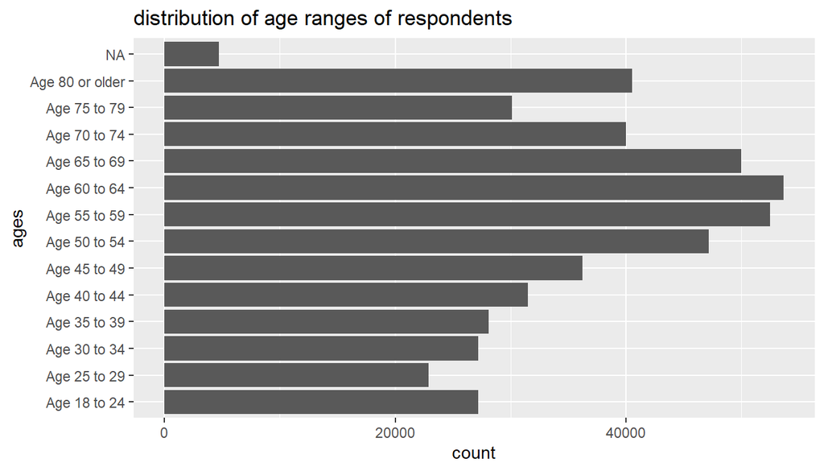

```r
ages<-brfss2013$X_ageg5yr
ggplot(data = brfss2013, aes(y = ages)) +  geom_bar() + labs(title="distribution of age ranges of respondents")
```

The plot above: ages represented fairly

#### Checking how different categories represented in the sample (Employment status):

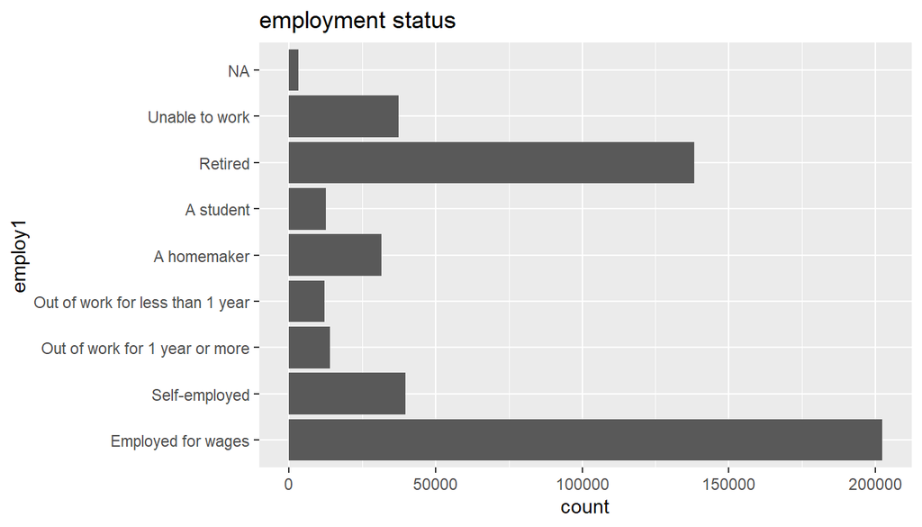

```r
ggplot(data = brfss2013, aes(y = employ1)) +  geom_bar() + labs(title="employment status")
```

The plot above: employment represented quite fairly

#### Checking how different categories represented in the sample (Income):

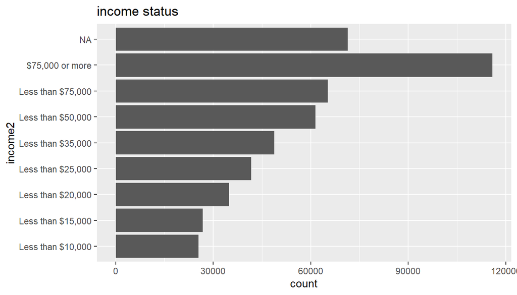

```r
ggplot(data = brfss2013, aes(y = income2)) +  geom_bar() + labs(title="income status")
```

The plot above: income groups represented quite fairly

#### Checking how different categories represented in the sample (Gender):

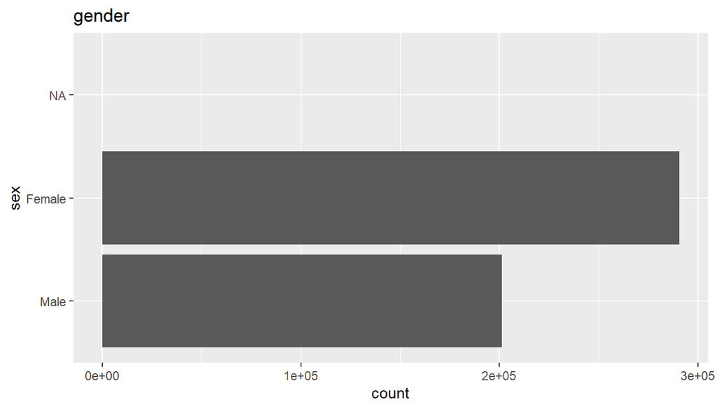

```r
ggplot(data = brfss2013, aes(y = sex)) +  geom_bar() + labs(title="gender")
```

The plot above: gender groups represented quite fairly

#### Checking how different categories represented in the sample (Race):

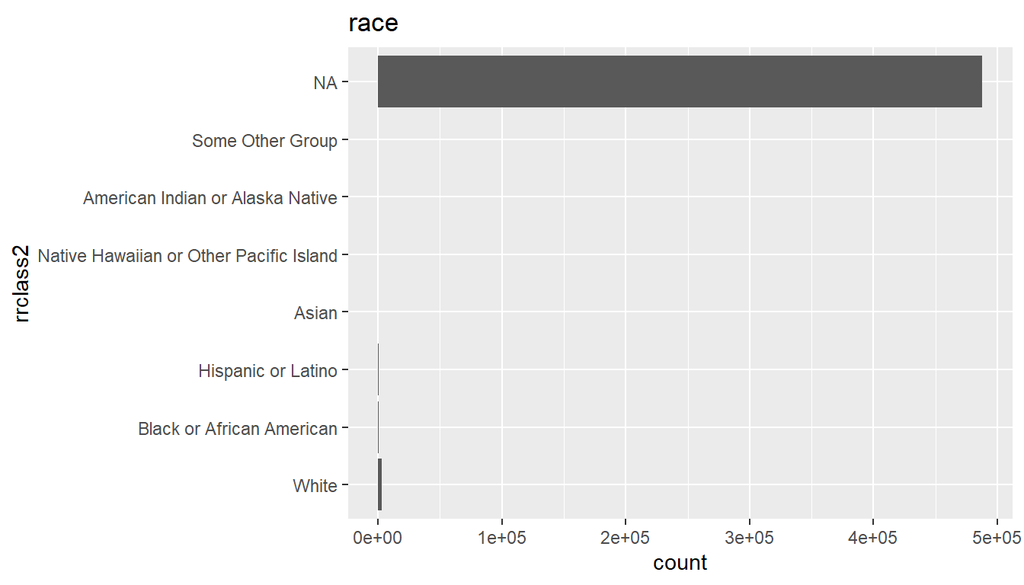

```r
ggplot(data = brfss2013, aes(y = rrclass2)) +  geom_bar() + labs(title="race")
```

The plot above: race groups are mostly - NA - not representative

#### Checking how different categories represented in the sample (Martial Status):

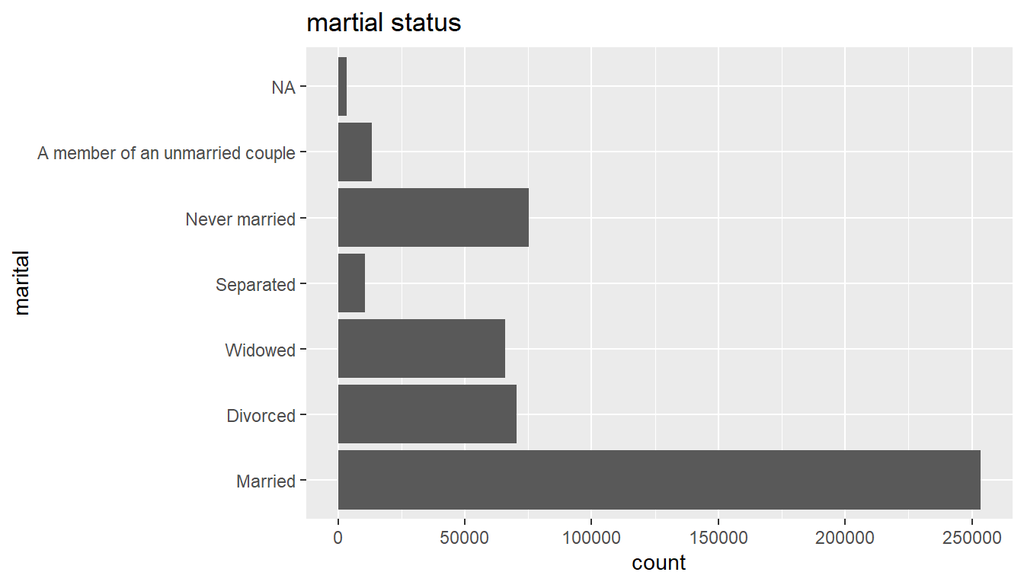

```r
ggplot(data = brfss2013, aes(y = marital)) +  geom_bar() + labs(title="martial status")
```

The plot above: marital groups are quite representative

## General observation, conclusion:

The data sample looks like sufficiently representative

Age, Gender, Employment, Income, Marital sub categories represented well.

Race queries are mostly NA -

so here we can not conclude we have an equal race representation

(and so the bias could be present here)

## Part 2: Research questions

**Research question 1:**

How severe and abrupt health accidents correlated with un/employment in the general population of USA?

**Research question 2:**

How severe and abrupt health accidents correlated with un/employment

in the states differently affected by unemployment?

**Research question 3:**

What is the ratio of fully disabled to all unemployed in the states where unemployment is most/less pronounced?

Note: In all 3 researches considered only two “severe and abrupt health accidents” :heart attack and stroke.

## Part 3: Exploratory data analysis

## Research question 1

#### Q: How severe and abrupt health accidents correlated with un/employment in the general population of USA?

#### While all my questions are relevant for a standard employment age only I filter out all the people older than 64 y.o.

```r
active_age<-subset(brfss2013, X_ageg5yr=="Age 18 to 24"
                   | X_ageg5yr=="Age 25 to 29"
                   | X_ageg5yr=="Age 30 to 34"
                   | X_ageg5yr=="Age 35 to 39"
                   | X_ageg5yr=="Age 40 to 44"
                   | X_ageg5yr=="Age 45 to 49"
                   | X_ageg5yr=="Age 50 to 54"
                   | X_ageg5yr=="Age 55 to 59"
                   | X_ageg5yr=="Age 60 to 64")
```

#### I leave only people with defined employment status

#### and defined heart attack/stroke status:

```r
active_age<-active_age %>%
  filter(!is.na(employ1))%>%
  filter(!is.na(cvdinfr4))%>%
  filter(!is.na(cvdstrk3))
```

Explore affected population:

```r
#Explore heart attack population
active_age %>%
  group_by(cvdinfr4) %>%
  summarise(diagnozed_heart_attack=n()) %>%
  arrange(diagnozed_heart_attack)
```

```
## # A tibble: 2 x 2
##   cvdinfr4 diagnozed_heart_attack
##   <fct>                     <int>
## 1 Yes                       10140
## 2 No                       312667
```

```r
#Explore stroke population
active_age %>%
  group_by(cvdstrk3) %>%
  summarise(diagnozed_stroke=n()) %>%
  arrange(diagnozed_stroke)
```

```
## # A tibble: 2 x 2
##   cvdstrk3 diagnozed_stroke
##   <fct>               <int>
## 1 Yes                  7524
## 2 No                 315283
```

The tables above: show numbers of diagnosed or not with relevant issues

#### Separate affected population:

```r
#Separate heart attack population
heart_attack_population<-active_age %>%
  filter(cvdinfr4=="Yes")

#Separate stroke population
stroke_population<-active_age %>%
  filter(cvdstrk3=="Yes")
```

#### Explore heart attack employment status:

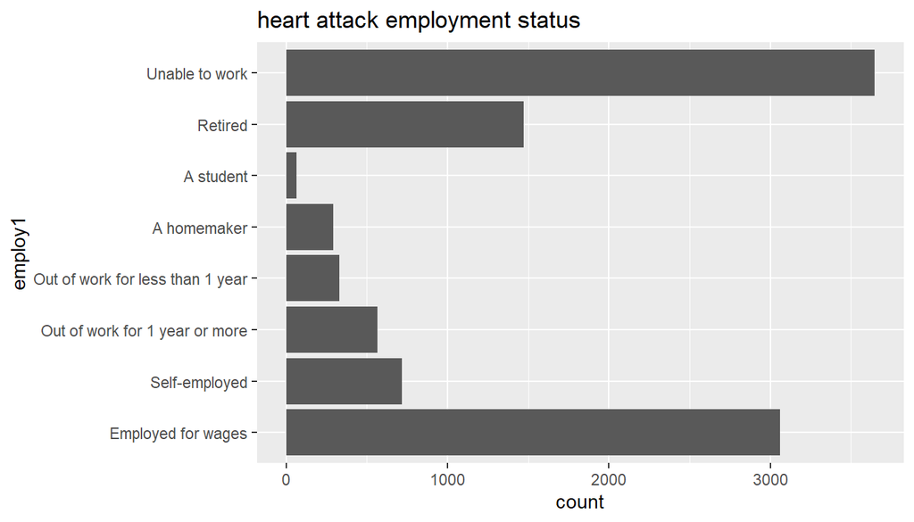

```r
ggplot(data = heart_attack_population, aes(y = employ1)) +  geom_bar() + labs(title="heart attack employment status")
```

The plot above: shows employment categories of suffered heart attack

#### Explore stroke employment status:

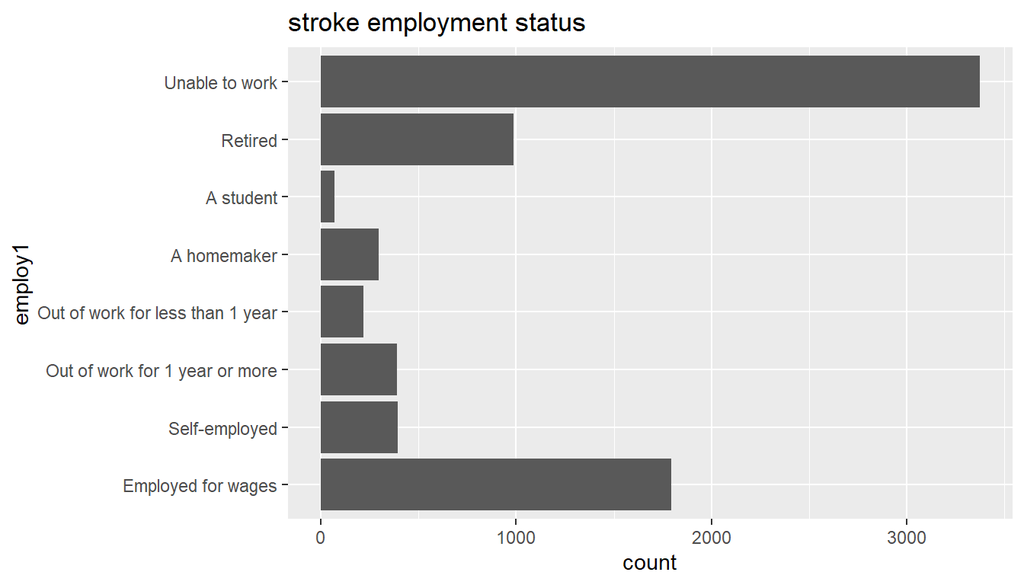

```r
ggplot(data = stroke_population, aes(y = employ1)) +  geom_bar() + labs(title="stroke employment status")
```

The plot above: shows employment categories of suffered stroke

#### Marking employed and unemployed in heart attack population:

```r
heart_attack_population <- heart_attack_population %>%
  mutate(heart_attack_unemployed = ifelse(employ1=="Unable to work"
                                           | employ1=="Out of work for 1 year or more"
                                           | employ1=="Out of work for less than 1 year",
    "not_employed",
    "employed")
    )
```

#### Explore comparative graph of unemployment in heart attack population:

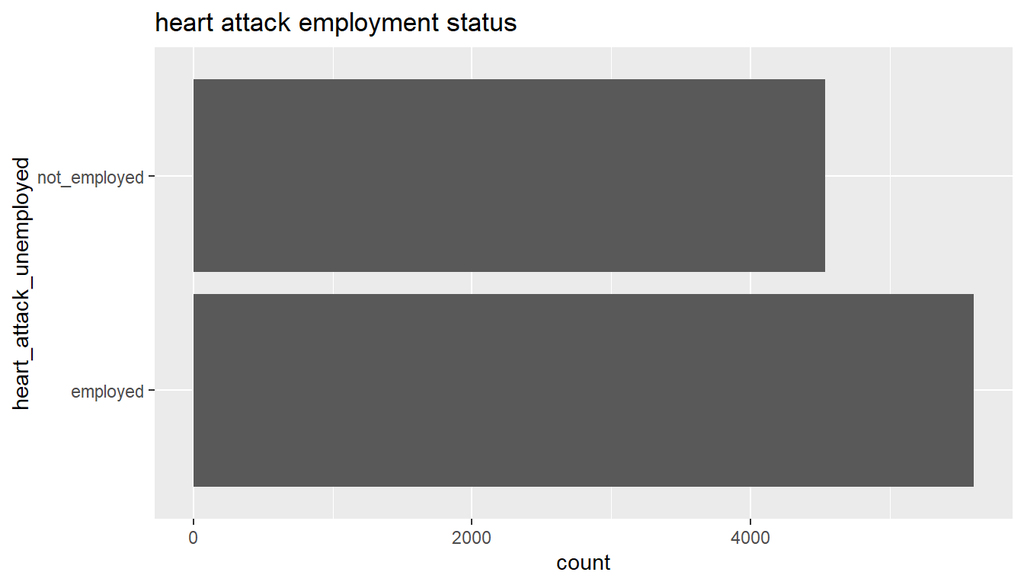

```r
ggplot(data = heart_attack_population, aes(y = heart_attack_unemployed)) +  geom_bar() + labs(title="heart attack employment status")
```

The plot above: shows general employment status of suffered heart attack

#### Marking employed and unemployed in stroke population:

```r
#marking employed and unemployed
stroke_population <- stroke_population %>%
  mutate(stroke_unemployed = ifelse(employ1=="Unable to work"
                                           | employ1=="Out of work for 1 year or more"
                                           | employ1=="Out of work for less than 1 year",
    "not_employed",
    "employed")
    )
```

#### Explore comparative graph of unemployment in stroke population:

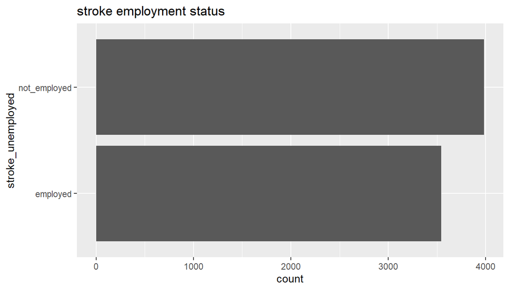

```r
ggplot(data = stroke_population, aes(y = stroke_unemployed)) +  geom_bar() + labs(title="stroke employment status")
```

The plot above: shows general employment status of suffered stroke

#### Create an additional column in general work age population

```r
#marking employed and unemployed
active_age <- active_age %>%
  mutate(mark_unemployed = ifelse(employ1=="Unable to work"
                                           | employ1=="Out of work for 1 year or more"
                                           | employ1=="Out of work for less than 1 year",
    "not_employed",
    "employed")
    )
```

#### Explore comparative graph of unemployment in general population:

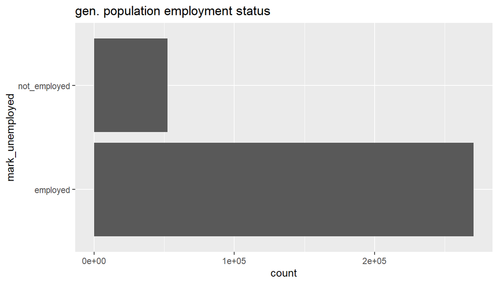

```r
ggplot(data = active_age, aes(y = mark_unemployed)) +  geom_bar() + labs(title="gen. population employment status")
```

The plot above: shows the general population employment status

#### c) stroke population

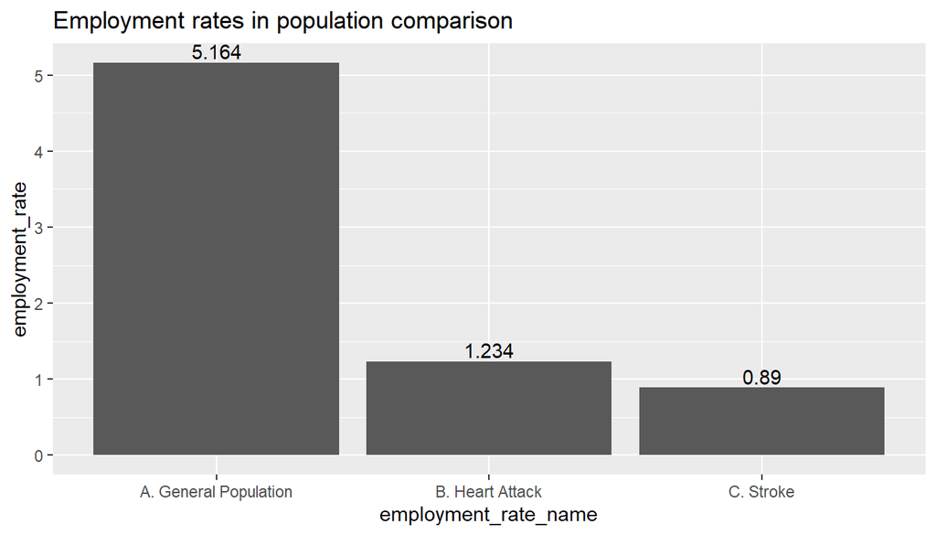

```r
eployment_ratio_gen_pop      <- round(sum(active_age$mark_unemployed == "employed") / sum(active_age$mark_unemployed == "not_employed"),3)

eployment_ratio_heart_attack <- round(sum(heart_attack_population$heart_attack_unemployed == "employed") / sum(heart_attack_population$heart_attack_unemployed == "not_employed"),3)

eployment_ratio_stroke       <- round(sum(stroke_population$stroke_unemployed == "employed") / sum(stroke_population$stroke_unemployed == "not_employed"),3)

employment_rate = c(eployment_ratio_gen_pop, eployment_ratio_heart_attack, eployment_ratio_stroke)

employment_rate_name = c('A. General Population', 'B. Heart Attack', 'C. Stroke')

comparative_rate<- data.frame(employment_rate, employment_rate_name)

ggplot(data = comparative_rate, aes(employment_rate_name, employment_rate, label=employment_rate)) +  geom_bar(stat='identity') + labs(title="Employment rates in population comparison") + geom_text(position=position_dodge(width=0.9), vjust=-0.25)
```

The EDA 1 summary plot above shows: the differences in employment rates of different populations - general, suffered heart attack and suffered stroke

## Summary EDA 1:

In general population the ratio of employed to unemployed is 5.16,

in heart attack population it is 1.23

and in stroke population it is 0.89

That means almost half of the population affected by heart attack is not employed.

More than a half of population affected by stroke is not employed.

This is significantly different from the high employment rate of the population in general.

## Research question 2:

#### Q:

#### How severe and abrupt health accidents correlated with un/employment

#### in the states differently affected by unemployment?

#### Prepare a relevant data set with employment status available:

```r
active_age<-subset(brfss2013, X_ageg5yr=="Age 18 to 24"
                   | X_ageg5yr=="Age 25 to 29"
                   | X_ageg5yr=="Age 30 to 34"
                   | X_ageg5yr=="Age 35 to 39"
                   | X_ageg5yr=="Age 40 to 44"
                   | X_ageg5yr=="Age 45 to 49"
                   | X_ageg5yr=="Age 50 to 54"
                   | X_ageg5yr=="Age 55 to 59"
                   | X_ageg5yr=="Age 60 to 64")

#Leave only population with defined employment, heart attack and stroke status
#(That does not mean they are sick, that means that status is defined)
active_age <- active_age %>%
  filter(!is.na(employ1))%>%
  filter(!is.na(cvdinfr4))%>%
  filter(!is.na(cvdstrk3))
```

#### Add employment marking and sort States by unemployment rate:

```r
active_age <- active_age %>%
  mutate(mark_unemployed = ifelse(employ1=="Unable to work"
                                           | employ1=="Out of work for 1 year or more"
                                           | employ1=="Out of work for less than 1 year",
    "not_employed",
    "employed")
    )

#find an unemployment ratio differences between different states
unemployment_ratio_by_state <- active_age %>%
  group_by(X_state) %>%
  summarise(unemployed = sum(mark_unemployed == "not_employed") / n()) %>%
  select(X_state, unemployed)

#Sort states by unemployment rate(sorting requires data type change)
unemployment_ratio_by_state_ordered = unemployment_ratio_by_state
unemployment_ratio_by_state_ordered$unemployed <- as.numeric(as.character(unemployment_ratio_by_state_ordered$unemployed))
unemployment_ratio_by_state_ordered<-unemployment_ratio_by_state_ordered[order(unemployment_ratio_by_state_ordered$unemployed),]
```

#### Designate 2 states categories in the ordered frame:

#### 10 best - states with lowest unemployment rate

#### 10 worst - states with highest unemployment rate

```r
states_10_best    <- unemployment_ratio_by_state_ordered[1:10,]
states_10_worst   <- unemployment_ratio_by_state_ordered[44:53,]
```

#### Showing two charts:

#### 1. States with lowest unemployment rate

#### 2. States with highest unemployment rate

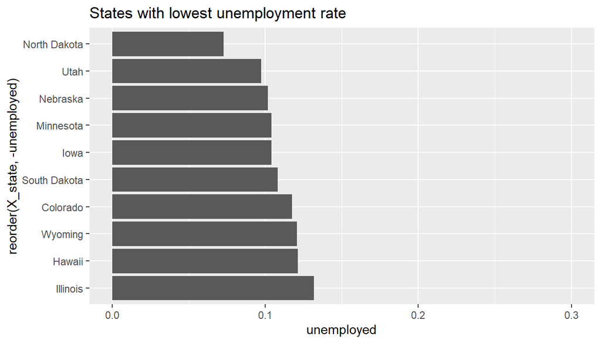

```r
ggplot(data = states_10_best, aes(x=unemployed, y=reorder(X_state,-unemployed) ,label=unemployed)) +  geom_bar(stat='identity') + labs(title="States with lowest unemployment rate") + xlim(0, 0.30)
```

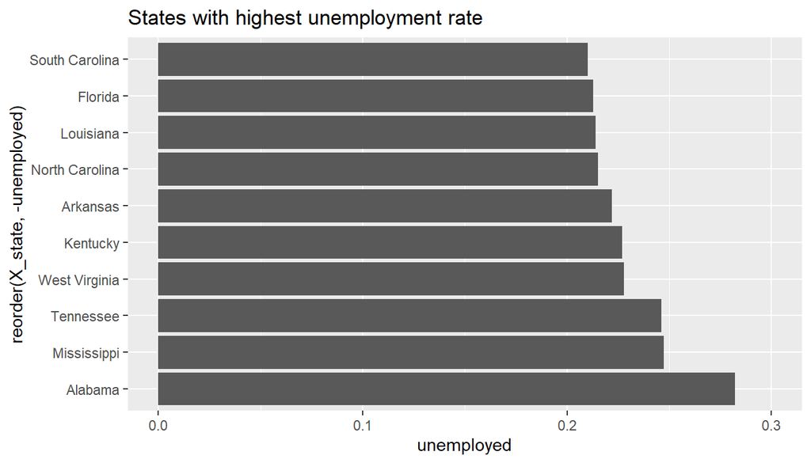

```r
ggplot(data = states_10_worst, aes(x=unemployed, y=reorder(X_state,-unemployed) ,label=unemployed)) +  geom_bar(stat='identity') + labs(title="States with highest unemployment rate") + xlim(0, 0.30)
```

The 2 plots above show

1. Unemployment rate in 10 states with the lowest unemployment
2. Unemployment rate in 10 states with the highest unemployment

#### Create 4 groups by disease (heart/stroke) and unemployment rate of the state (high/low):

```r
#Separate population of best employment states
best_empl_population <- subset(active_age, X_state %in% states_10_best$X_state)

#Separate population of worst employment states
worst_empl_population <- subset(active_age, X_state %in% states_10_worst$X_state)

#Separate heart attack population of best employment states
heart_attack_population_best <-best_empl_population %>%
  filter(cvdinfr4=="Yes")

#Separate stroke population of best employment states
stroke_population_best<-best_empl_population %>%
  filter(cvdstrk3=="Yes")

#Separate heart attack population of worst employment states
heart_attack_population_worst <-worst_empl_population %>%
  filter(cvdinfr4=="Yes")

#Separate stroke population of worst employment states
stroke_population_worst<-worst_empl_population %>%
  filter(cvdstrk3=="Yes")
```

#### Displaying a comparative analysis of heart attack/stroke rate in:

#### a) high employment states

#### b) lower employment states

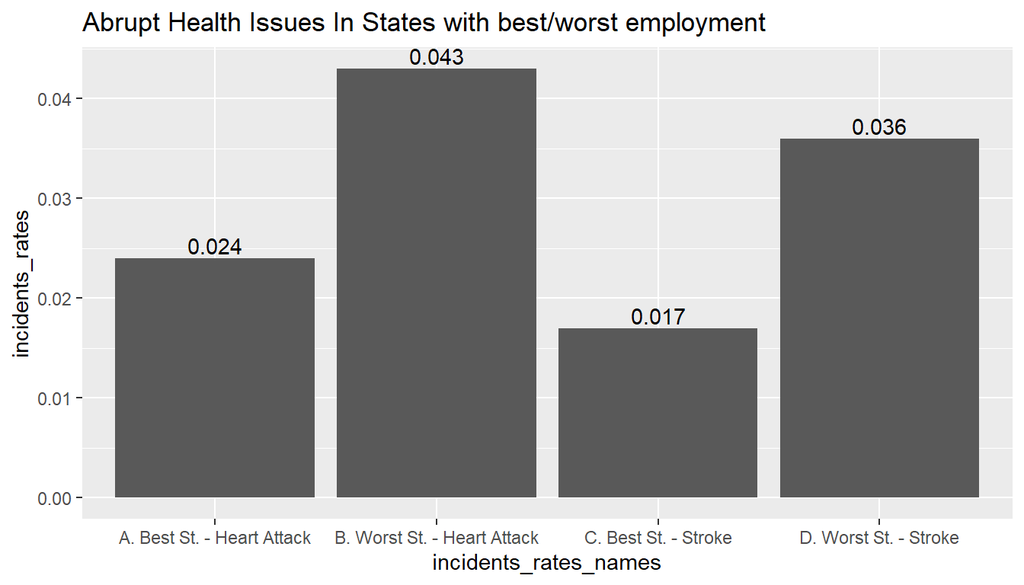

```r
best_states_heart_attack_ratio      <- as.numeric(round(count(heart_attack_population_best) / count(best_empl_population),3))
best_states_stroke_ratio            <- as.numeric(round(count(stroke_population_best) / count(best_empl_population),3))
worst_states_heart_attack_ratio     <- as.numeric(round(count(heart_attack_population_worst) / count(worst_empl_population),3))
worst_states_stroke_ratio           <- as.numeric(round(count(stroke_population_worst) / count(worst_empl_population),3))

incidents_rates = c(best_states_heart_attack_ratio, worst_states_heart_attack_ratio, best_states_stroke_ratio, worst_states_stroke_ratio)

incidents_rates_names = c('A. Best St. - Heart Attack', 'B. Worst St. - Heart Attack', 'C. Best St. - Stroke', 'D. Worst St. - Stroke')

compare_states_accidents<- data.frame(incidents_rates, incidents_rates_names)

ggplot(data = compare_states_accidents, aes(incidents_rates_names, incidents_rates, label=incidents_rates)) +  geom_bar(stat='identity') + labs(title="Abrupt Health Issues In States with best/worst employment") + geom_text(position=position_dodge(width=0.9), vjust=-0.25)
```

The summary plot for EDA 2 above: It demonstrates how 10 best and 10 worst (‘worst’/‘best’ by unemployment level) states are different in heart attack and stroke rates in population.

## Summary EDA 2:

Comparing 10 states with the highest unemployment and 10 states with the lowest unemployment,

found that heart / stroke issues are positively correlated with the unemployment ratio in states.

This research supports the correlation found in the first research on the different level.

## Research question 3:

#### Q: What is the ratio of fully disabled to all unemployed in the states where unemployment is most/less pronounced?

#### Continue to explore best/worst states here

#### But now the point is ‘the complete inability to work’

```r
#Adding disabled marking
active_age <- active_age %>%
  mutate(mark_disabled = ifelse(employ1=="Unable to work",
    "disabled",
    "not_disabled")
    )
```

#### Separate populations of ‘best’/‘worst’ states (Meaning: States with low/high unemployment rate respectively)

```r
#Separate population of best employment states
best_empl_population <- subset(active_age, X_state %in% states_10_best$X_state)

#Separate population of worst employment states
worst_empl_population <- subset(active_age, X_state %in% states_10_worst$X_state)
```

#### Now a series of calculations of disability level for 4 categories:

#### 1. Best state/Heart attack

```r
#Find the ratio of disabled to all unemployed with the heart attack in the states with the best employment
heart_attack_population_best <- best_empl_population %>%
  filter(cvdinfr4=="Yes")

heart_attack_population_best_disabled <-heart_attack_population_best %>%
  filter(mark_disabled=="disabled")

heart_attack_population_best_unemployed <-heart_attack_population_best %>%
  filter(mark_unemployed=="not_employed")

ratio_disabled_heart_best <-as.numeric(round(count(heart_attack_population_best_disabled) / count(heart_attack_population_best_unemployed),3))

print(ratio_disabled_heart_best)
```

```
## [1] 0.761
```

#### 2. Worst state/Heart attack

```r
#Find the ratio of disabled to all unemployed with the heart attack in the states with the worst employment
heart_attack_population_worst <- worst_empl_population %>%
  filter(cvdinfr4=="Yes")

heart_attack_population_worst_disabled <-heart_attack_population_worst %>%
  filter(mark_disabled=="disabled")

heart_attack_population_worst_unemployed <-heart_attack_population_worst %>%
  filter(mark_unemployed=="not_employed")

ratio_disabled_heart_worst <-as.numeric(round(count(heart_attack_population_worst_disabled) / count(heart_attack_population_worst_unemployed),3))

print(ratio_disabled_heart_worst)
```

```
## [1] 0.863
```

#### 3. Best state/stroke

```r
#Find the ratio of disabled to all unemployed with the stroke in the states with the best employment
stroke_population_best <- best_empl_population %>%
  filter(cvdstrk3=="Yes")

stroke_population_best_disabled <-stroke_population_best %>%
  filter(mark_disabled=="disabled")

stroke_population_best_unemployed <-stroke_population_best %>%
  filter(mark_unemployed=="not_employed")

ratio_disabled_stroke_best <-as.numeric(round(count(stroke_population_best_disabled) / count(stroke_population_best_unemployed),3))

print(ratio_disabled_stroke_best)
```

```
## [1] 0.802
```

#### 3. Worst state/stroke

```r
#Find the ratio of disabled to all unemployed with the stroke in the states with the worst employment
stroke_population_worst <- worst_empl_population %>%
  filter(cvdstrk3=="Yes")

stroke_population_worst_disabled <-stroke_population_worst %>%
  filter(mark_disabled=="disabled")

stroke_population_worst_unemployed <-stroke_population_worst %>%
  filter(mark_unemployed=="not_employed")

ratio_disabled_stroke_worst <-as.numeric(round(count(stroke_population_worst_disabled) / count(stroke_population_worst_unemployed),3))

print(ratio_disabled_stroke_worst)
```

```
## [1] 0.887
```

#### Demonstrate in the graph how ratio of disabled to unemployed correlates with the

#### unemployment rate in the States with best / worst employment

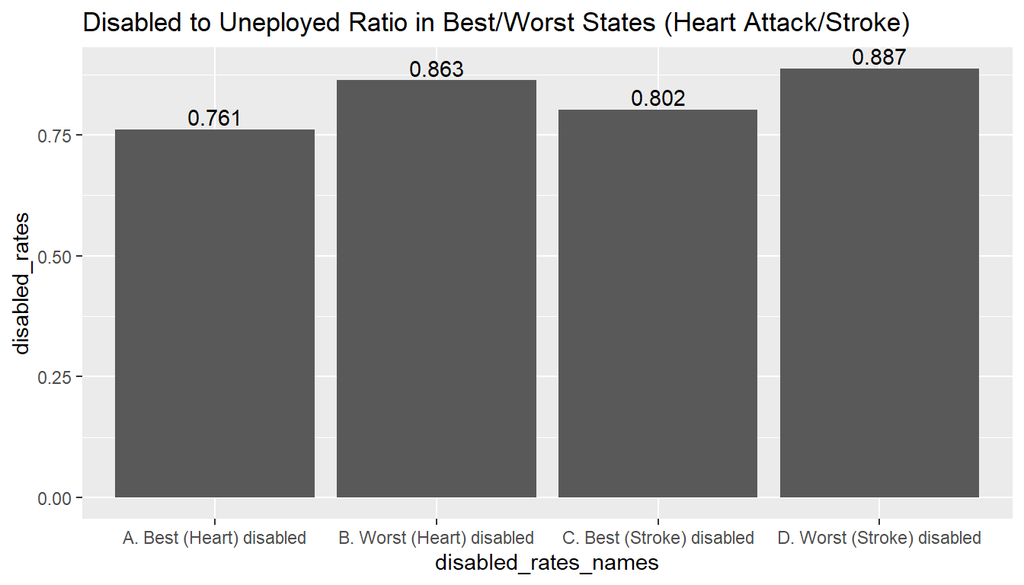

```r
disabled_rates = c(ratio_disabled_heart_best, ratio_disabled_heart_worst, ratio_disabled_stroke_best, ratio_disabled_stroke_worst)

disabled_rates_names = c('A. Best (Heart) disabled', 'B. Worst (Heart) disabled', 'C. Best (Stroke) disabled', 'D. Worst (Stroke) disabled')

compare_states_accidents<- data.frame(disabled_rates, disabled_rates_names)

ggplot(data = compare_states_accidents, aes(disabled_rates_names, disabled_rates, label=disabled_rates)) +  geom_bar(stat='identity') + labs(title="Disabled to Uneployed Ratio in Best/Worst States (Heart Attack/Stroke)") + geom_text(position=position_dodge(width=0.9), vjust=-0.25)
```

The summary for EDA 3 plot above: it demonstrates that disability ration is correlated with the unemployment level, when compared 10 states with the highest unemployment and 10 states with the lowest unemployment.

## Summary EDA 3:

It is visible that in states with higher unemployment (“Worst States”) ratio of disabled

to unemployed is higher,

considering two population groups: a group suffered heart attack and a group suffered stroke.

For example (1):

In Best States(States with lower unemployment):

Those who suffered heart attack have 0.76 disabled rate

In Worst States(States with higher unemployment):

Those who suffered heart attack have 0.86 disabled rate

For example (2):

In Best States(States with lower unemployment):

Those who suffered stroke have 0.8 disabled rate

In Worst States(States with higher unemployment):

Those who suffered stroke have 0.89 disabled rate

## Overall summary:

#### It is better to be employed and healthy and to live in a ‘best state’ :)

#### One affects the other - which one, which other - is not clear, but they are correlated.

#### That I wish you, my dear reviewer:

#### great health and superb employment :) !